# oefeningen hoofdstuk 7 - De XÃ,Â² kwadraat toets

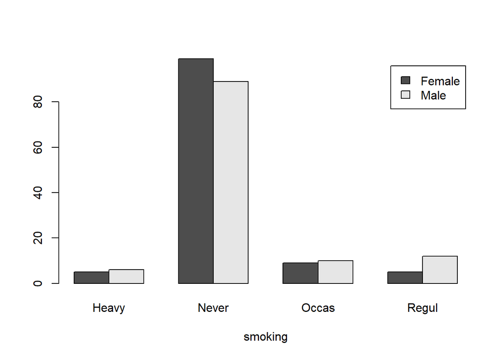

```r
barplot(kruistabelO3, xlab = "smoking" , beside = TRUE, legend=rownames(kruistabelO3))
```

#### onderzoek 4:

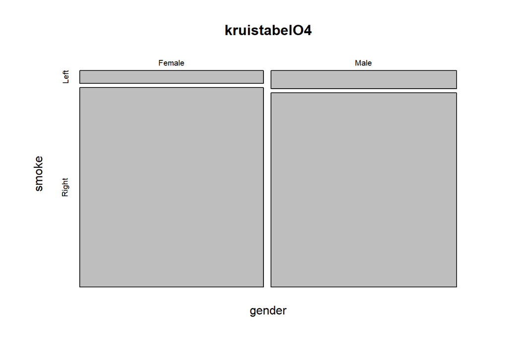

```r
plot(kruistabelO4, ylab = 'smoke', xlab = 'gender')
```

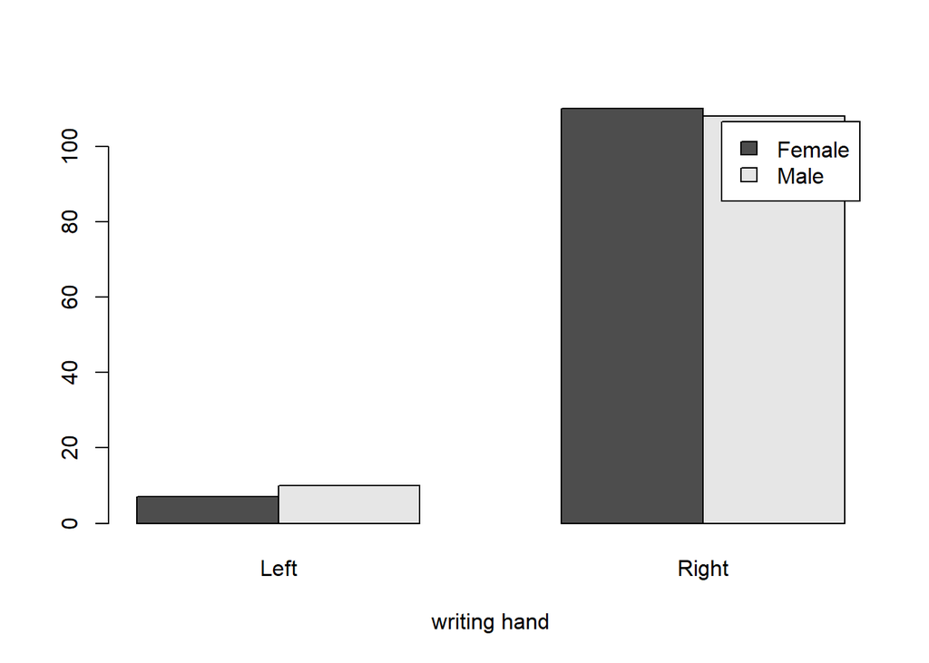

```r
barplot(kruistabelO4, xlab = 'writing hand', beside = TRUE, legend=rownames(kruistabelO4))
```

### d

#### onderzoek 1:

hoog

#### onderzoek 2:

laag

#### onderzoek 3:

laag

#### onderzoek 4:

laag

### e / f

#### onderzoek 1:

```r
chisq.test(kruistabelO1)
```

```
##
##  Pearson's Chi-squared test
##
## data:  kruistabelO1
## X-squared = 5.4885, df = 6, p-value = 0.4828
```

```r
df01 <- (nrow(kruistabelO1)-1) * (ncol(kruistabelO1)-1)
df01
```

```
## [1] 6
```

```r
qchisq(0.95, df01)
```

```
## [1] 12.59159
```

chi² = 5.48 vrijheidsgraden = 6 grenswaarde = 12.59 p-value = 0.48

#### onderzoek 2:

```r
chisq.test(kruistabelO2)
```

```
##
##  Pearson's Chi-squared test
##
## data:  kruistabelO2
## X-squared = 1.5814, df = 2, p-value = 0.4535
```

```r
df02 <- (nrow(kruistabelO2)-1) * (ncol(kruistabelO2)-1)
df02
```

```
## [1] 2
```

```r
qchisq(0.95, df02)
```

```
## [1] 5.991465
```

chi² = 1.58 vrijheidsgraden = 2 grenswaarde = 5.99 p-value = 0.45

#### onderzoek 3:

```r
chisq.test(kruistabelO3)
```

```
##
##  Pearson's Chi-squared test
##
## data:  kruistabelO3
## X-squared = 3.5536, df = 3, p-value = 0.3139
```

```r
df03 <- (nrow(kruistabelO3)-1) * (ncol(kruistabelO3)-1)
df03
```

```
## [1] 3
```

```r
qchisq(0.95, df03)
```

```
## [1] 7.814728
```

chi² = 3.55 vrijheidsgraden = 3 grenswaarde = 7.81 p-value = 0.31

#### onderzoek 4:

```r
chisq.test(kruistabelO4)
```

```
##
##  Pearson's Chi-squared test with Yates' continuity correction
##
## data:  kruistabelO4
## X-squared = 0.23563, df = 1, p-value = 0.6274
```

```r
df04 <- (nrow(kruistabelO4)-1) * (ncol(kruistabelO4)-1)
df04
```

```
## [1] 1
```

```r
qchisq(0.95, df04)
```

```
## [1] 3.841459
```

chi² = 0.24 vrijheidsgraden = 1 grenswaarde = 3.84 p-value = 0.62

### g

#### onderzoek 1:

de nulhypothese wordt NIET verworpen, p (0.48) is groter dan alpha (0.05)

we hebben een representatieve steekproef, chi²(5.48) is kleiner dan de grenswaarde (12.59)

#### onderzoek 2:

de nulhypothese mag NIET verworpen worden, p (0.45) is groter dan alpha (0.05)

we hebben een representatieve steekproef, chi²(1.58) is kleiner dan de grenswaarde (5.99)

#### onderzoek 3:

de nulhypothese mag NIET verworpen worden, p (0.31) is groter dan alpha (0.05)

we hebben een representatieve steekproef, chi² (3.55) is kleiner dan de grenswaarde (7.81)

#### onderzoek 4:

chi² = 0.24 vrijheidsgraden = 1 grenswaarde = 3.84 p-valu = 0.62

we hebben een representatieve steekproef, chi² (0.24) is kleiner dan de grenswaarde (3.84)

# oefening 7.3.

## opgave

Laad de dataset Aids2 uit package MASS (zie Oefening 7.2) die informatie bevat over 2843 patiënten die vóór 1991 in Australië met AIDS besmet werden. Deze dataset werd in detail besproken door Ripley en Solomon (2007). Onderzoek of er een relatie is tussen de variabele geslacht (Sex) en de manier van besmetting (T.categ).

1. Ga op de gebruikelijke manier te werk: visualiseren van de data, chi², g en p-waarde berekenen (alpha = 0,05), en tenslotte een conclusie formuleren.
2. Bepaal de gestandaardiseerde residuën om te bepalen welke categorieën extreme waarden bevatten.

## oplossing

```r
library(MASS)

attach(Aids2)
```

### deel 1

```r
aidsKruistabel <- table(sex, T.categ)
aidsKruistabel
```

```
##    T.categ
## sex   hs hsid   id  het haem blood mother other
##   F    1    0   20   20    0    37      4     7
##   M 2464   72   28   21   46    57      3    63
```

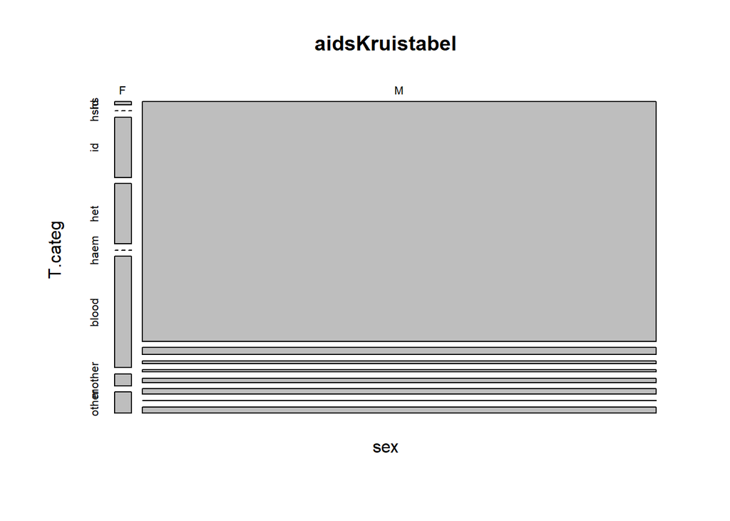

```r
plot(aidsKruistabel)
```

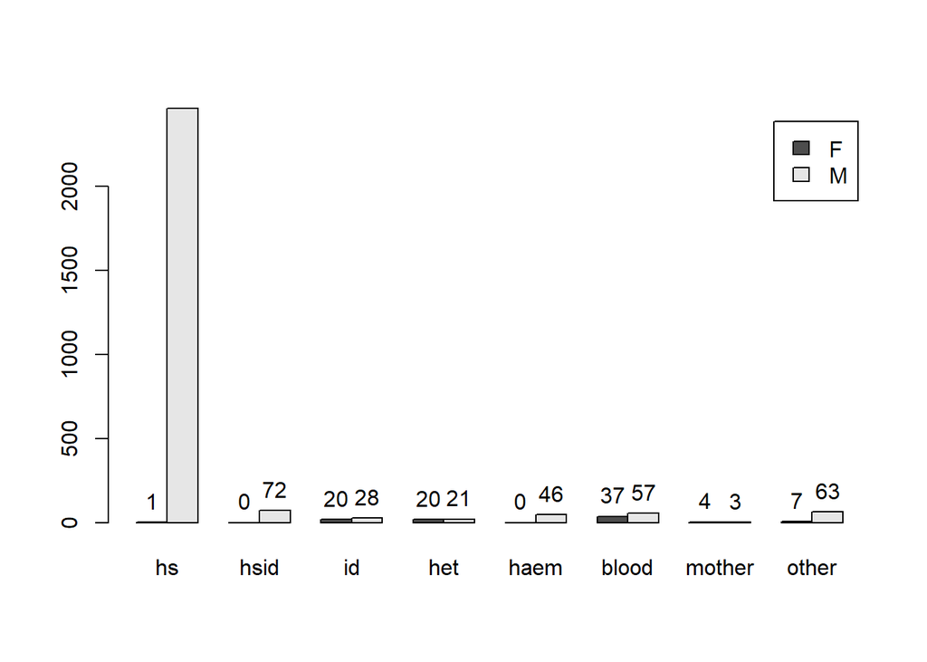

```r
bp <- barplot(aidsKruistabel, beside = TRUE, legend=rownames(aidsKruistabel))
text(bp, aidsKruistabel, aidsKruistabel, pos = '3')
```

```r
summary(aidsKruistabel)
```

```
## Number of cases in table: 2843
## Number of factors: 2
## Test for independence of all factors:
##  Chisq = 1083.4, df = 7, p-value = 1.157e-229
##  Chi-squared approximation may be incorrect
```

```r
vrijheidsgraden <- (nrow(aidsKruistabel) -1 )* (ncol(aidsKruistabel)-1)
vrijheidsgraden
```

```
## [1] 7
```

```r
grens <- qchisq(0.95, vrijheidsgraden)
grens
```

```
## [1] 14.06714
```

geen representatieve steekproef aangezien dat chi² groter is dan de grenswaarde

# oefening 7.4.

## opdracht

Elk jaar voert Imec (voorheen iMinds) een studie uit over het gebruik van digitale technologieën in Vlaanderen, de Digimeter (Vanhaelewyn & De Marez, 2016). In deze oefening zullen we nagaan of de steekproef van de Digimeter 2016 (n = 2164) representatief is voor de bevolking wat betreft de leeftijdscategorieën van de deelnemers. In Tabel 7.2a worden de relatieve frequencies van de deelnemers weergegeven. De absolute frequenties voor de verschillende leeftijdscategorieën van de Vlaamse bevolking worden samengevat in Tabel 7.2b. Deze gegevens zijn ook te vinden in bijgevoegd CSV-bestand oefeningen/data/bestat-vl-ages.csv.

1. De tabel met leeftijdsgegevens van de Vlaamse bevolking als geheel heeft meer categorieën dan deze gebruikt in de Digimeter. Maak een samenvatting zodat je dezelfde categorieën overhoudt dan deze van de Digimeter. Tip: dit gaat misschien makkelijker in een rekenblad dan in R.
2. Om de goodness-of-fit test te kunnen toepassen hebben we de absolute frequenties nodig van de geobserveerde waarden in de steekproef. Bereken deze.
3. Bereken ook de verwachte percentages (??i) voor de populatie als geheel.
4. Voer de goodness-of-fit test uit over de verdeling van leeftijdscategorieën in de steekproef van de Digimeter. Is de steekproef in dit opzicht inderdaad representatief voor de Vlaamse bevolking?

## oplossing

```r
technologiegebruikt <- read.csv("C:\\Users\\tijsm\\Google Drive\\HoGent 2018-2019\\2e semester\\Onderzoekstechnieken\\files\\onderzoekstechnieken-cursus\\oefeningen\\data\\hfst7_chikwadraat\\bestat-vl-ages.csv")

technologiegebruikt
```

| age.group | population |
| --- | --- |
| 0-5 | 352017 |
| 5-9 | 330320 |
| 10-14 | 341303 |
| 15-19 | 366648 |
| 20-24 | 375469 |
| 25-29 | 387131 |
| 30-34 | 401285 |
| 35-39 | 409587 |
| 40-44 | 458485 |
| 45-49 | 493720 |

[output cut: 11 more lines]

# interessante libraries

gplots graphics - interessant voor examen blijkbaar visualize - duidelijk tonen van toetsen